# R Lab 1: Welcome to Posit Cloud!

Author

Grading Rubric

[output not shown]

```r
library(tidyverse)
```

## Remember – Question the Arson

You can load data files into R using functions from different packages. Typically, we will work with data that are stored in a Comma Separated Values file (a .csv). For this format of data, we will use the `read_csv()` function to read in our data.

```r
# To run the code, hit the green "play" button in the top right of this code chunk.
# You should type code for question 1 below this line.

head(arson_data)
```

```
# A tibble: 6 × 7
  Question Question_Text             Crime_Scene_Answer Suspect_Response Outcome
     <dbl> <chr>                     <lgl>              <lgl>            <chr>
1        1 One of the fires was sta… FALSE              FALSE            Correct
2        2 Matches were used to set… TRUE               TRUE             Correct
3        3 The trash was on the cur… FALSE              TRUE             Incorr…
4        4 There was a doghouse in … FALSE              FALSE            Correct
5        5 The residence of the thi… TRUE               TRUE             Correct
6        6 The second residence had… TRUE               FALSE            Incorr…
# ℹ 2 more variables: Time_to_Response_seconds <dbl>,
#   Action_During_Response <chr>
```

2. **What are the observations in this data set?**

   Each of the questions
3. **How many observations are there in the data set?** *Hint: you can use code to find this or look in the top right environment.*

   16 observations/questions
4. **What are the variables in this data set? What are their data types?**

   required – Crime_Scene_Answer (C), Suspect Response (C), Outcome (C), Time_to_Response_sections (N), Action_During_Response (C)
5. **How many variables are there in the data set?** *Hint: you can use code to find this or look in the top right environment.*

   7 (will also accept 5 or 6)

You can also embed plots in the rendered document. Here is an example of a plot:

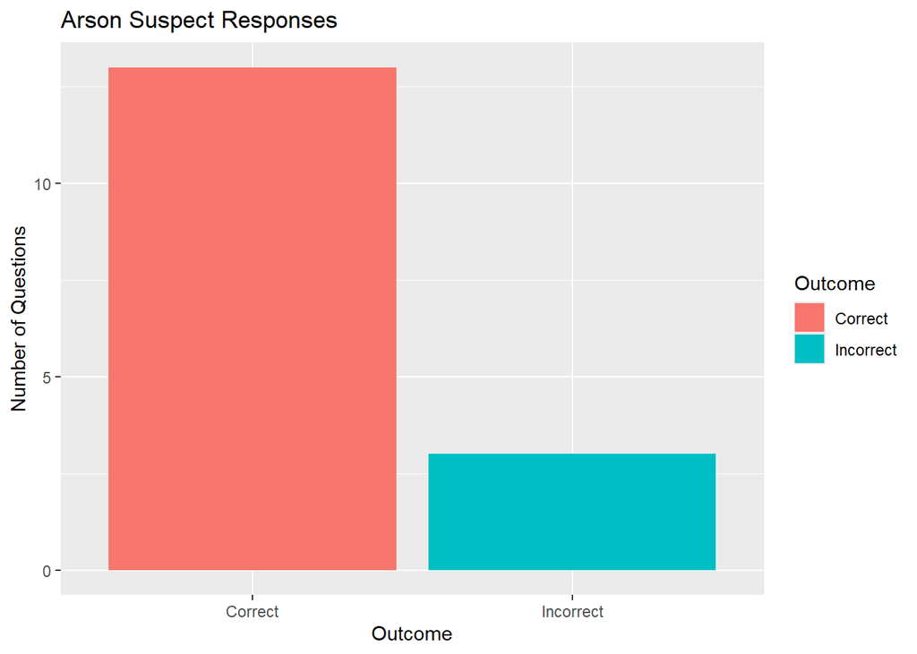

## Childcare Costs in San Luis Obispo

6. **Load in and preview the SLO childcare data set in the following code chunk. You may need to look in the data folder to find the name of the .csv file.**

```r
# Write your code below this line.
slo_childcare <- read_csv("data/slo_childcare.csv")
# You may choose to write more code below this line to help you answer the next couple of questions.
head(slo_childcare)
```

```
# A tibble: 6 × 12
  county_name     state_abbreviation study_year total_pop  mcsa mfccsa mc_infant
  <chr>           <chr>                   <dbl>     <dbl> <dbl>  <dbl>     <dbl>
1 San Luis Obisp… CA                       2008    262238  144.   129.      242.
2 San Luis Obisp… CA                       2009    262149  154.   131.      259.
3 San Luis Obisp… CA                       2010    265577  172.   129.      276.
4 San Luis Obisp… CA                       2011    267871  189.   127.      293.
5 San Luis Obisp… CA                       2012    270121  207    125.      310.
6 San Luis Obisp… CA                       2013    272094  183.   137.      299.
# ℹ 5 more variables: mc_toddler <dbl>, mc_preschool <dbl>, mfcc_infant <dbl>,
#   mfcc_toddler <dbl>, mfcc_preschool <dbl>
```

```r
glimpse(slo_childcare)
```

```
Rows: 11
Columns: 12
$ county_name        <chr> "San Luis Obispo County", "San Luis Obispo County",…
$ state_abbreviation <chr> "CA", "CA", "CA", "CA", "CA", "CA", "CA", "CA", "CA…
$ study_year         <dbl> 2008, 2009, 2010, 2011, 2012, 2013, 2014, 2015, 201…
$ total_pop          <dbl> 262238, 262149, 265577, 267871, 270121, 272094, 274…
$ mcsa               <dbl> 144.05, 154.28, 171.85, 189.43, 207.00, 183.08, 159…
$ mfccsa             <dbl> 128.81, 131.11, 129.17, 127.24, 125.30, 137.24, 149…
$ mc_infant          <dbl> 241.81, 259.31, 276.07, 292.82, 309.58, 298.58, 287…
$ mc_toddler         <dbl> 170.44, 197.45, 208.06, 218.67, 229.28, 217.08, 204…
$ mc_preschool       <dbl> 170.44, 197.45, 208.06, 218.67, 229.28, 217.08, 204…
$ mfcc_infant        <dbl> 160.47, 160.83, 178.23, 195.62, 213.02, 202.65, 192…
$ mfcc_toddler       <dbl> 145.65, 152.12, 165.86, 179.61, 193.35, 185.41, 177…
$ mfcc_preschool     <dbl> 145.65, 152.12, 165.86, 179.61, 193.35, 185.41, 177…
```

```r
names(slo_childcare)
```

```
 [1] "county_name"        "state_abbreviation" "study_year"
 [4] "total_pop"          "mcsa"               "mfccsa"
 [7] "mc_infant"          "mc_toddler"         "mc_preschool"
[10] "mfcc_infant"        "mfcc_toddler"       "mfcc_preschool"
```

7. **What are the observational units in this data set?**

   Each of the year
8. **What are the variables in this data set? Also describe what information the variables contain, don’t just list the names of the variables.**

   *A description of the data can be found [here](https://github.com/rfordatascience/tidytuesday/blob/master/data/2023/2023-05-09/readme.md).*
   - county_name – county (SLO)
   - state_abbreviation – state (CA)
   - study_year – the year of data collection
   - total_pop – county population that year
   - mcsa – median weekly cost of school age childcare at center based care
   - mfccsa – median weekly cost of school age childcare at family based care
   - mc_infant – median weekly cost of infant childcare at center based care
   - mfcc_infant – median weekly cost of infant childcare at family based care
   - mc_preschool – median weekly cost of preschool childcare at center based care
   - mfcc_preschool – median weekly cost of preschool childcare at family based care
   - mc_toddler – median weekly cost of toddlers childcare at center based care
   - mfcc_toddler – median weekly cost of toddlers childcare at family based care
9. **Suggest one categorical variable that you could measure about the observational units.**

   *It is worth it to note that we don’t have data for individual households. Carefully consider your observational unit here.*

   Make sure it can be measured on a year in SLO county – e.g., Drought/No Drought, Who the Mayor is, proportion of women who work, etc.
10. **Could we use this data set to say anything about the cost of childcare in Santa Barbara County? Explain your answer.**

    No, since this data was only collected in SLO, it might not be representative of Santa Barbara